# Practical Machine Learning - Course Project

Ash Thompson

05 November 2021

# Overview

This is the report for the course project of Practical Machine Learning. The goal of this project is to predict the manner in which they did the exercise. This is the "classe" variable in the training set.

# Summary

The initial data was extensive with 160 variables, but most were not useful due to large amounts of N/A's or having no variance. So I cleaned out those variables, and the obivous label and ID variables, leaving me with 54 remaining to model.

The training set was then split into training and validation, leaving the testing set for later as the 20 cases will be used for the quiz portion.

Models were built using the training data, and tested against the validation data.

The first model was built using a decision tree. It was fast to run but had poor accuracy.

The second model was built using Random Forest, which took a long time to run but did have great accuracy at 99.7%. The settings that I chose were the ones that seemed to reduce the run time the best without compromising accuracy.

The model I chose to use for the quiz was the Random Forest.

# Stage 1 - Reading the CSVs and setting up the enviroment

```r
library(caret)
library(dplyr)
library(rattle)
```

```r
set.seed(900)

fileUrlTrain = "https://d396qusza40orc.cloudfront.net/predmachlearn/pml-training.csv"
fileUrlTest = "https://d396qusza40orc.cloudfront.net/predmachlearn/pml-testing.csv"

trainingOrig <- read.csv(url(fileUrlTrain))
testingOrig  <- read.csv(url(fileUrlTest))
```

# Stage 2 - Cleaning the data

# Clean out variables with high amount of NAs

```r
NAsTraining <- sapply(trainingOrig, function(x) mean(is.na(x))) < 0.80
NAsTesting  <- sapply(testingOrig, function(x) mean(is.na(x))) < 0.80

training <- trainingOrig[, which(NAsTraining)]
testing  <- testingOrig[, which(NAsTesting)]
```

# using nearZeroVar function to tag and remove columns with near zero variance

```r
NZV <- nearZeroVar(training)

training <- training[,-NZV]
testing <- testing[,-NZV]
```

# remove ID, name and timestamps from both

```r
training <- training[,-(1:5)]
testing <- testing[,-(1:5)]
```

# Stage 3 - split off a validation set from the training set

```r
inTrain <-createDataPartition(training$classe, p = 0.8, list=FALSE)
validation <- training[-inTrain,]
training <- training[inTrain,]
```

# Stage 4 - creating the models

## model 1 - Decision Tree using rpart method in train

```r
fitRPart <- train(classe ~ ., data=training, method="rpart")

# R Part Prediction

predRPart <- predict(fitRPart, validation)

cmRPart <- confusionMatrix(predRPart, validation$classe)

cmRPart
```

```
## Confusion Matrix and Statistics
##
##           Reference
## Prediction   A   B   C   D   E
##          A 981 193 106 101  25
##          B   7 236  22 108  54
##          C 123 330 556 404 184
##          D   0   0   0   0   0
##          E   5   0   0  30 458
##
## Overall Statistics
##
##                Accuracy : 0.5687
##                  95% CI : (0.553, 0.5843)
##     No Information Rate : 0.2845
##     P-Value [Acc > NIR] : < 2.2e-16
##
##                   Kappa : 0.4491
##
##  Mcnemar's Test P-Value : < 2.2e-16
##
## Statistics by Class:
##
##                      Class: A Class: B Class: C Class: D Class: E
## Sensitivity            0.8790  0.31094   0.8129   0.0000   0.6352
## Specificity            0.8486  0.93963   0.6786   1.0000   0.9891
## Pos Pred Value         0.6977  0.55269   0.3482      NaN   0.9290
## Neg Pred Value         0.9464  0.85040   0.9450   0.8361   0.9233
## Prevalence             0.2845  0.19347   0.1744   0.1639   0.1838
## Detection Rate         0.2501  0.06016   0.1417   0.0000   0.1167
## Detection Prevalence   0.3584  0.10885   0.4071   0.0000   0.1257
## Balanced Accuracy      0.8638  0.62528   0.7457   0.5000   0.8121
```

```r
cmRPart$overall['Accuracy']
```

```
##  Accuracy
## 0.5686974
```

# model 2 - Random Forest using rf method in train

```r
control <- trainControl(method="cv", number=3, verboseIter=FALSE, allowParallel = TRUE)
fitRF <- train(classe ~ ., data=training, method="rf", trControl=control, tuneLength = 5)


# Random Forest prediction

predRF <- predict(fitRF, validation)

cmRF <- confusionMatrix(predRF, validation$classe)

cmRF
```

```
## Confusion Matrix and Statistics
##
##           Reference
## Prediction    A    B    C    D    E
##          A 1115    1    0    0    0
##          B    0  757    1    0    0
##          C    0    1  683    3    0
##          D    0    0    0  640    2
##          E    1    0    0    0  719
##
## Overall Statistics
##
##                Accuracy : 0.9977
##                  95% CI : (0.9956, 0.999)
##     No Information Rate : 0.2845
##     P-Value [Acc > NIR] : < 2.2e-16
##
##                   Kappa : 0.9971
##
##  Mcnemar's Test P-Value : NA
##
## Statistics by Class:
##
##                      Class: A Class: B Class: C Class: D Class: E
## Sensitivity            0.9991   0.9974   0.9985   0.9953   0.9972
## Specificity            0.9996   0.9997   0.9988   0.9994   0.9997
## Pos Pred Value         0.9991   0.9987   0.9942   0.9969   0.9986
## Neg Pred Value         0.9996   0.9994   0.9997   0.9991   0.9994
## Prevalence             0.2845   0.1935   0.1744   0.1639   0.1838
## Detection Rate         0.2842   0.1930   0.1741   0.1631   0.1833
## Detection Prevalence   0.2845   0.1932   0.1751   0.1637   0.1835
## Balanced Accuracy      0.9994   0.9985   0.9987   0.9974   0.9985
```

```r
cmRF$overall['Accuracy']
```

```
##  Accuracy
## 0.9977058
```

# Conclusion

The Random Forest model had a very high accuracy, so will be used for the quiz predictions.

## Appendix - Plots and details

Decision Tree:

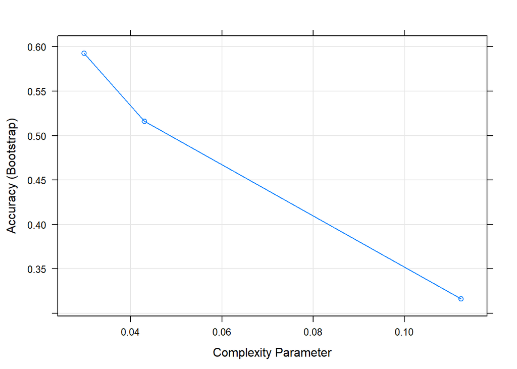

```
## Confusion Matrix and Statistics
##
##           Reference
## Prediction   A   B   C   D   E
##          A 981 193 106 101  25
##          B   7 236  22 108  54
##          C 123 330 556 404 184
##          D   0   0   0   0   0
##          E   5   0   0  30 458
##
## Overall Statistics
##
##                Accuracy : 0.5687
##                  95% CI : (0.553, 0.5843)
##     No Information Rate : 0.2845
##     P-Value [Acc > NIR] : < 2.2e-16
##
##                   Kappa : 0.4491
##
##  Mcnemar's Test P-Value : < 2.2e-16
##
## Statistics by Class:
##
##                      Class: A Class: B Class: C Class: D Class: E
## Sensitivity            0.8790  0.31094   0.8129   0.0000   0.6352
## Specificity            0.8486  0.93963   0.6786   1.0000   0.9891
## Pos Pred Value         0.6977  0.55269   0.3482      NaN   0.9290
## Neg Pred Value         0.9464  0.85040   0.9450   0.8361   0.9233
## Prevalence             0.2845  0.19347   0.1744   0.1639   0.1838
## Detection Rate         0.2501  0.06016   0.1417   0.0000   0.1167
## Detection Prevalence   0.3584  0.10885   0.4071   0.0000   0.1257
## Balanced Accuracy      0.8638  0.62528   0.7457   0.5000   0.8121
```

Random Forest:

```
## Confusion Matrix and Statistics
##
##           Reference
## Prediction    A    B    C    D    E
##          A 1115    1    0    0    0
##          B    0  757    1    0    0
##          C    0    1  683    3    0
##          D    0    0    0  640    2
##          E    1    0    0    0  719
##
## Overall Statistics
##
##                Accuracy : 0.9977
##                  95% CI : (0.9956, 0.999)
##     No Information Rate : 0.2845
##     P-Value [Acc > NIR] : < 2.2e-16
##
##                   Kappa : 0.9971
##
##  Mcnemar's Test P-Value : NA
##
## Statistics by Class:
##
##                      Class: A Class: B Class: C Class: D Class: E
## Sensitivity            0.9991   0.9974   0.9985   0.9953   0.9972
## Specificity            0.9996   0.9997   0.9988   0.9994   0.9997
## Pos Pred Value         0.9991   0.9987   0.9942   0.9969   0.9986
## Neg Pred Value         0.9996   0.9994   0.9997   0.9991   0.9994
## Prevalence             0.2845   0.1935   0.1744   0.1639   0.1838
## Detection Rate         0.2842   0.1930   0.1741   0.1631   0.1833
## Detection Prevalence   0.2845   0.1932   0.1751   0.1637   0.1835
## Balanced Accuracy      0.9994   0.9985   0.9987   0.9974   0.9985
```